# Statistical inference with the GSS data

## Setup

### Load packages

```r
library(ggplot2)
library(dplyr)
library(statsr)
```

### Load data

```r
load("gss.Rdata")
```

## Part 1: Data

### Survey Scope and Applicability

The GSS gathers data on contemporary American society in order to monitor and explain trends and constants in attitudes, behaviors, and attributes. Hundreds of trends have been tracked since 1972. In addition, since the GSS adopted questions from earlier surveys, trends can be followed for up to 70 years.

The GSS contains a standard core of demographic, behavioral, and attitudinal questions, plus topics of special interest. Among the topics covered are civil liberties, crime and violence, intergroup tolerance, morality, national spending priorities, psychological well-being, social mobility, and stress and traumatic events.

GSS data are used in numerous newspaper, magazine, and journal articles, by legislators, policy makers, and educators. The GSS is also a major teaching tool in colleges and universities: more than 27,000 journal articles, books, reports, and Ph.D. dissertations are based on the GSS, and about 400,000 students use the GSS in their classes each year.

### Survey Design

The vast majority of GSS data are obtained in face-to-face interviews. Computer-assisted personal interviewing (CAPI) began in the 2002 GSS. Under some conditions when it has proved difficult to arrange an in-person interview with a sampled respondent, GSS interviews may be conducted by telephone.

The target population of the GSS is adults (18+) living in households in the United States. From 1972 to 2004, participation in the GSS was limited to respondents who were able to do interviews in English, but since 2006, the GSS interview has been translated into and administered in Spanish, so that both English-and Spanish-speaking U.S. residents are currently included in the target population. The average responce rate for the survey is about 0.75.

In general, the GSS samples closely resemble distributions reported in the Census and other authoritative sources. Because of survey non-response, sampling variation, and various other factors the GSS sample does deviate from known population figures for some variables.

The database for this Coursera project contains data points collected between 1972-2012. This subset mostly includes only questions that were included every year or almost every year. All missing values are denoted by NA in the dataset.

### Generalizability / Causality

GSS is structured as an observational study with no random assignment, which means that the resulting data can’t be used to establish causality. At the same time, the sampling for the study is random, which makes the results of the study generalizable to the 18+ years old adults living in households in the United States. The generalization should be used with caution, however, due to the potential sampling and non-responce bias for the reasons described above (e.g., underrepresentation of the non-English speaking individuals in the data collected before 2006.) For the purposes of this research project, the potential bias will be considered insignificant.

## Part 2: Research question

Climate change is considered by a large number of scientists worldwide as one of the most significant challenges, which humanity is facing in the 21st century, and the role of the US in fighting this challenge is crucial.

The recent 2016 presidential elections were won by a conservative Republican party candidate, who is strongly against spending the country’s budget on fighting the climate change. This victory, though, is not necessarily a proof of the low level of support for the climate change-related spending among the Republican voters as compared to the voters of other political affiliations.

**Do the GSS survey data show convincing evidence that the voters with different political views have different levels of support for the climate change-related spending?**

## Part 3: Exploratory data analysis

### Defining and Preparing the Variables of Interest

Since the voting age in the US is 18 years old, and since the GSS survey covers people who are at least 18 years old, we can consider all respondents of the survey to be eligible voters.

To answer the research question, we will need to examine the following two variables:

**`partyid`**: Political party affiliation

**Survey question**: Generally speaking, do you usually think of yourself as a Republican, Democrat, Independent, or what?

**Response levels**:

```r
summary(gss$partyid)
```

```
##    Strong Democrat   Not Str Democrat       Ind,Near Dem
##               9117              12040               6743
##        Independent       Ind,Near Rep Not Str Republican
##               8499               4921               9005
##  Strong Republican        Other Party               NA's
##               5548                861                327
```

**`natenvir`**: Improving and protecting environment

**Survey question**: We are faced with many problems in this country, none of which can be solved easily or inexpensively. I’m going to name some of these problems, and for each one I’d like you to tell me whether you think we’re spending too much money on it, too little money, or about the right amount. b. Improving and protecting the environment.

**Response levels**:

```r
summary(gss$natenvir)
```

```
##  Too Little About Right    Too Much        NA's
##       19259        9539        2816       25447
```

Additionally, let’s also check if the support for the climate change-related spending varies by the respondents’ self-evaluated level of conservatism, which will give us a checkpoint beyond the party affiliation lines. For that, we will need to look at the following variable:

**`polviews`**: Think of self as liberal or conservative

**Survey question**: We hear a lot of talk these days about liberals and conservatives. I’m going to show you a seven-point scale on which the political views that people might hold are arranged from extremely liberal - point 1 - to extremely conservative - point. Where would you place yourself on this scale?

**Response levels**:

```r
summary(gss$polviews)
```

```
##     Extremely Liberal               Liberal      Slightly Liberal
##                  1330                  5582                  6181
##              Moderate Slightly Conservative          Conservative
##                 18494                  7691                  7092
##  Extrmly Conservative                  NA's
##                  1506                  9185
```

Now, let’s keep only the variables we need and filter out the NAs. As we have seen above, the answers about environment protection have the largest number of NAs (~45% of all data) but the amount of non-NA data is sufficiently large to make statistically-significant conclusions.

Additionally, there are very few supporters of the parties that are other than Republican or Democratic, so we can filter such responders out to minimize the number of levels we have.

To filter out the NAs, I’ll use the `filter` function from the package dplyr. To select the columns we need, I’ll use the `select` function from the same package. The `partyid` and `polviews` variables are filtered for NAs separately to keep as much useful data to be compared to `natenvir` as possible.

```r
natenvir_partyid <- gss %>% select(partyid, natenvir) %>% filter(partyid != "Other Party") %>% filter(!is.na(natenvir)) %>% filter(!is.na(partyid))

natenvir_polviews <- gss %>% select(natenvir, polviews) %>% filter(!is.na(natenvir)) %>% filter(!is.na(polviews))
```

Let’s visualise the data we’ve got. First, let’s look at how the willingness to support environment-related spending changes with party affiliation:

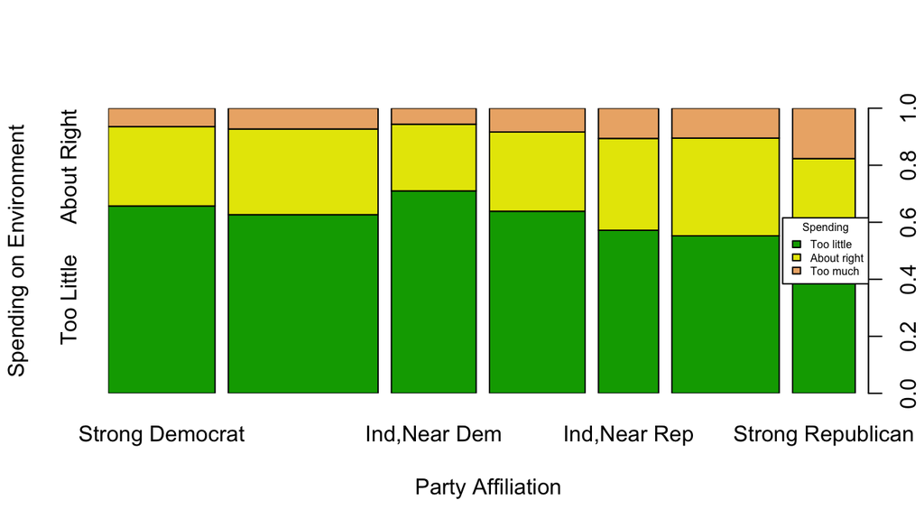

```r
plot(natenvir_partyid$partyid, natenvir_partyid$natenvir, xlab="Party Affiliation", ylab="Spending on Environment", col=terrain.colors(4), ann = T)

legend("right", cex=0.5, title="Spending", c("Too little", "About right", "Too much"), fill=terrain.colors(4))
```

The share of the responders who think that the US government spends too much on environment protection visibly increases as the party affiliation changes from Strong Democrat to Strong Republican.

Next, let’s look beyond the party lines and see how the environment protection-related spending is supported by the liberals vs. conservatives in general:

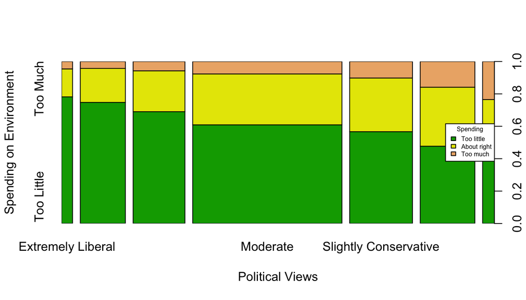

```r
plot(natenvir_polviews$polviews, natenvir_polviews$natenvir, xlab="Political Views", ylab="Spending on Environment", col=terrain.colors(4), ann = T)

legend("right", cex=0.5, title="Spending", c("Too little", "About right", "Too much"), fill=terrain.colors(4))
```

Here we see the same and even clearer correlation - the more conservative the survey respondent is, the more that responder thinks that the US government spends too much on protecting the environment.

## Part 4: Inference

### Method and Hypotheses

Since we have two categorical variables and at least one of them has more than two levels, we’ll need to use the chi-square independence test for the statistical inference. Due to the specifics of this method, we will not be able to define the confidence interval.

The hypotheses for this test are as follows:

H<sup>0</sup>: The responder’s opinion about environment protection-related government spending is independent from his/her political affiliation/views (“there’s nothing going on”).

H<sup>A</sup>: The responder’s opinion about environment protection-related government spending is dependent on his/her political affiliation/views.

### Checking the conditions

- Since GSS study is using the random sampling, the sampled observations can be considered to be independent
- The study covers significantly less than 10% of the US population
- Each observed case contributes to only one category of the responce
- Each particular scenario has much more than 5 cases

Hence, we may conclude that the chi-square method can be used appropriately.

### Inference Test

Lets perform the test for political affiliation and for political views separately. Let’s start with the political affiliation and use the `inference` function from the statsr package. This function helps to build the tables of the expected vs. observed counts, as well as the chi-square distribution graph.

```r
inference(y = natenvir, x = partyid, data = natenvir_partyid, statistic = "proportion", type = "ht", alternative = "greater", method = "theoretical" )
```

```
## Response variable: categorical (3 levels)
## Explanatory variable: categorical (8 levels)
## Observed:
##                     y
## x                    Too Little About Right Too Much
##   Strong Democrat          3262        1381      320
##   Not Str Democrat         4360        2092      506
##   Ind,Near Dem             2797         921      221
##   Independent              2838        1235      370
##   Ind,Near Rep             1599         900      296
##   Not Str Republican       2756        1710      522
##   Strong Republican        1249        1148      514
##
## Expected:
##                     y
## x                    Too Little About Right Too Much
##   Strong Democrat      3019.878   1502.9739 440.1486
##   Not Str Democrat     4233.792   2107.1312 617.0772
##   Ind,Near Dem         2396.796   1192.8701 349.3342
##   Independent          2703.469   1345.4993 394.0319
##   Ind,Near Rep         1700.697    846.4259 247.8774
##   Not Str Republican   3035.089   1510.5448 442.3658
##   Strong Republican    1771.280    881.5549 258.1650
##
## H0: partyid and natenvir are independent
## HA: partyid and natenvir are dependent
## chi_sq = 852.349, df = 12, p_value = 0
```

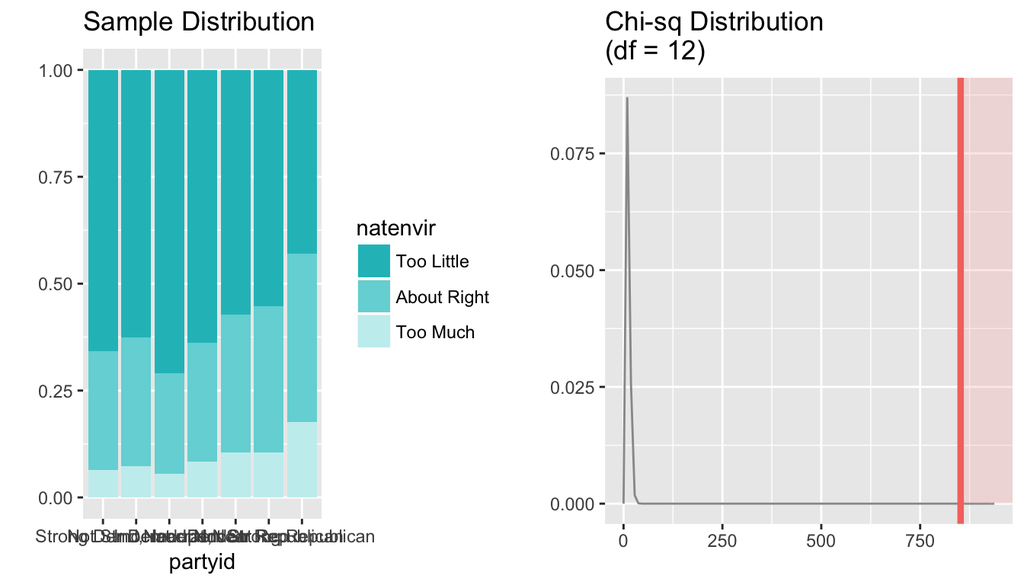

The p-value for this test is close to zero, we reject the null-hypothesis and conclude that the responder’s opinion about environment protection-related government spending is dependent on his/her political affiliation/views.

To get another proof-point, let’s do the chi-square test for the level of spending support vs. the general political views:

```r
inference(y = natenvir, x = polviews, data = natenvir_polviews, statistic = "proportion", type = "ht", alternative = "greater", method = "theoretical" )
```

```
## Response variable: categorical (3 levels)
## Explanatory variable: categorical (7 levels)
## Observed:
##                        y
## x                       Too Little About Right Too Much
##   Extremely Liberal            598         132       35
##   Liberal                     2354         661      134
##   Slightly Liberal            2497         913      208
##   Moderate                    6348        3273      800
##   Slightly Conservative       2485        1453      447
##   Conservative                1822        1390      606
##   Extrmly Conservative         368         264      194
##
## Expected:
##                        y
## x                       Too Little About Right  Too Much
##   Extremely Liberal       467.0180    229.2562  68.72582
##   Liberal                1922.4049    943.6963 282.89882
##   Slightly Liberal       2208.7205   1084.2468 325.03269
##   Moderate               6361.8231   3122.9785 936.19835
##   Slightly Conservative  2676.9595   1314.1024 393.93818
##   Conservative           2330.8167   1144.1831 343.00022
##   Extrmly Conservative    504.2574    247.5367  74.20592
##
## H0: polviews and natenvir are independent
## HA: polviews and natenvir are dependent
## chi_sq = 1120.8003, df = 12, p_value = 0
```

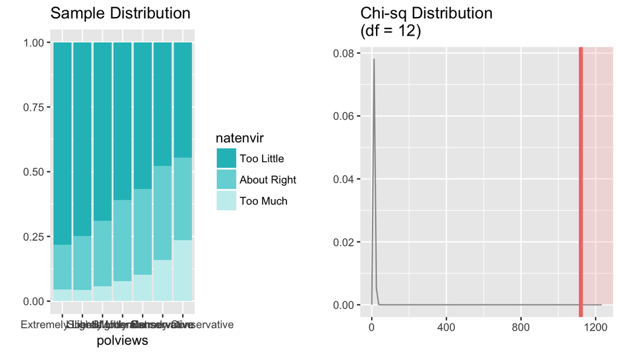

As mentioned in the first chapter, GSS is structured as an observational study with no random assignment, which means that the resulting data can’t be used to establish causality. We can, however, consider the results to be generalizable to the 18+ years old adults living in households in the United States.